# Approximation Methods

## dummy slide

# Introduction

## Presentation Outline

Introduction to mixed models with a probit link.

Discussion of available approximation methods.

Simulation example.

Real data example.

Next steps and alternatives.

# Three Models

## Why

Very similar marginal log-likelihood.

Many options for approximating the marginal log-likelihood.

## Notation

$$\begin{align*}
\phi^{(K)}(\vec x;\vec\mu,\mat\Sigma) &=
\frac 1{(2\pi)^{K/2}\lvert\mat\Sigma\rvert^{1/2}}\exp\left(
- \frac 12 (\vec x - \vec\mu)^\top\mat\Sigma^{-1}(\vec x - \vec\mu)
\right) \\
\Phi^{(K)}(\vec x;\vec\mu,\mat\Sigma) &=
\int_{-\infty}^{x_1} \cdots\int_{-\infty}^{x_K}
\phi^{(K)}(\vec z;\vec\mu,\mat\Sigma)\der z_1 \cdots \der z_K \\
\end{align*}$$
The standard case
$$\begin{align*}
\phi^{(K)}(\vec x) &= \phi^{(K)}(\vec x;\vec 0,\mat I) \\
\Phi^{(K)}(\vec x) &= \Phi^{(K)}(\vec x;\vec 0,\mat I) \\
\end{align*}$$
The univariate case
$$\begin{align*}
\phi(x; \mu, \sigma^2) &= \phi^{(1)}(x; \mu, \sigma^2) \\
\Phi(x; \mu, \sigma^2) &= \Phi^{(1)}(x; \mu, \sigma^2)
\end{align*}$$

## Generalization of Skew-normal Dist.

$$\begin{pmatrix}
\vec V_1 \\ \vec V_2
\end{pmatrix} \sim
N\left(
\begin{pmatrix}
\vec \xi_1 \\ \vec\xi_2
\end{pmatrix},
\begin{pmatrix}
\mat\Xi_{11} & \mat\Xi_{12} \\
\mat\Xi_{21} & \mat\Xi_{22}
\end{pmatrix}
\right)$$

then the density of $\vec V_1 = \vec v_1$ and $\vec V_2 \leq \vec v_2$ is

$$\begin{align*}
\phi^{(k_1)}(\vec v_1; \vec \xi_1, \mat\Xi_{11})
\Prob\left(\vec V_2 < \vec v_2 \,\middle\vert\,
\vec V_1 = \vec v_1
\right)\nonumber
\hspace{-140pt}& \\
&= \phi^{(k_1)}(\vec v_1; \vec \xi_1, \mat\Xi_{11}) \\
&\hspace{20pt}\cdot
\Phi^{(k_2)}\left(
\vec v_2
- \mat\Xi_{21}\mat\Xi_{11}^{-1}(\vec v_1 - \vec\xi_1);
\vec \xi_2,
\mat\Xi_{22} - \mat\Xi_{21}\mat\Xi_{11}^{-1}\mat\Xi_{12}
\right)
\end{align*}$$

## Generalization of Skew-normal Dist.

… and the marginal is

$$\begin{align*}
\Prob(\vec V_2 \leq \vec v_2) &=
\Phi^{(k_2)}(\vec v_2; \vec\xi_2, \mat\Xi_2) \\
&=
\int \phi^{(k_1)}(\vec v_1; \vec \xi_1, \mat\Xi_{11}) \\
&\hspace{30pt}\cdot
\Prob\left(\vec V_2 < \vec v_2 \,\middle\vert\,
\vec V_1 = \vec v_1
\right)\der v_{11} \cdots \der v_{1k_1}
\end{align*}$$

I.e. either $k_1$ or $k_2$-dimensional intractable integral.

## Three Models

We have $\vec Y = (Y_1,\dots,Y_n)^\top$ observed outcomes.

Mixed binomial

Outcomes $Y_i \in \{0,\dots,m\}$ are conditionally independent and binomially distributed.

Mixed multinomial

Outcomes $Y_i \in \{1,\dots,c\}$ are conditionally independent and multinomially distributed.

Mixed generalized survival model (GSM)

Outcomes $Y_i\in (0,\infty)$ are conditionally independently drawn from a GSM and potentially right censored.

## Mixed Binomial

Given random effect $\vec U \in \mathbb{R}^K$, each $Y_1, \dots, Y_n$ are

$$Y_i \sim \text{Bin}(\Phi(\vec x_i^\top\vec\beta + \vec z_i^\top\vec u), m)$$

with

$$\vec U \sim N(\vec 0, \mat\Sigma)$$

$\vec x_i$ and $\vec z_i$ are known covariates. $\vec x_i^\top\vec\beta$ is the fixed effect. $\vec\beta$ and $\mat\Sigma$ are unknown parameters. $\vec U$ is an unobservable random effect.

## Mixed Binomial Likelihood

The complete data likelihood is

$$\begin{align*}
p(\vec u, \vec y) &= c(\vec y) \phi^{(K)}(\vec u;\vec 0, \mat\Sigma) \\
&\hspace{20pt}\cdot\prod_{i = 1}^n
\Phi(\vec x_i^\top\vec\beta + \vec z_i^\top\vec u)^{y_i}
\Phi(-\vec x_i^\top\vec\beta - \vec z_i^\top\vec u)^{m - y_i}\\
c(\vec y) &= \prod_{i = 1}^n \begin{pmatrix}m \\ y_i\end{pmatrix}\nonumber
\end{align*}$$

The marginal log-likelihood is

$$l(\vec\beta,\mat\Sigma) = \log\int p(\vec u, \vec y)
\der u_1\cdots \der u_K$$

## Mixed Binomial Likelihood

Let $\mat X = (\vec x_1, \dots, \vec x_n)^\top$ and define

$$\begin{align*}
\vec j_i &= (\underbrace{1, \dots, 1}_{y_i\text{ times}},
\underbrace{-1, \cdots, -1}_{m - y_i\text{ times}})^\top \\
\widetilde{\mat X} &=
\begin{pmatrix}
\vec j_1 & \vec 0 & \cdots & \vec 0 \\
\vec 0 & \vec j_2 & \ddots & \vec \vdots \\
\vdots & \ddots & \ddots & \vec 0 \\
\vec 0 & \cdots & \vec 0 & \vec j_n
\end{pmatrix}\mat X
\end{align*}$$

and similarly $\mat Z$ and $\widetilde{\mat Z}$.

## Mixed Binomial Likelihood

Then

$$\begin{align*}
p(\vec u, \vec y) &= c(\vec y) \phi^{(K)}(\vec u;\vec 0, \mat\Sigma) \\
&\hspace{20pt}\cdot\prod_{i = 1}^n
\Phi(\vec x_i^\top\vec\beta + \vec z_i^\top\vec u)^{y_i}
\Phi(-\vec x_i^\top\vec\beta - \vec z_i^\top\vec u)^{m - y_i} \\
&= c(\vec y) \phi^{(K)}(\vec u;\vec 0, \mat\Sigma)
\Phi^{(nm)}(\widetilde{\mat X}\vec\beta + \widetilde{\mat Z}\vec u)
\end{align*}$$

I.e. we have a $K$ or $nm$-dimensional integral

as shown by Y. Pawitan et al. (2004) in the binary case and Ochi and Prentice (1984) in a more restricted case.

## Mixed Multinomial

We have $c$ categories.

$\mat Z_i = (\vec z_{i1}, \dots, \vec z_{ic})^\top \in \mathbb{R}^{c\times K}$: known random effect covariates.

$\mat B = (\vec \beta_1, \dots, \vec\beta_c)^\top$: fixed effect coefficients.

We observe $Y_1,\dots, Y_n \in \{1,\dots,c\}$ with

$$Y_i = k \Leftrightarrow \forall k \neq k':\, A_{ik} > A_{ik'},
\qquad k,k'\in\{1,\dots,c\}$$
where $\vec A_i$ is a latent variable.

## Mixed Multinomial Cont.

Assume
$$\vec A_i \mid \vec U = \vec u \sim N(\mat B\vec x_i + \mat Z_i \vec u, \mat I)$$

then
$$\begin{align*}
\mathcal{C}_{ik} &= \left\{
\vec A_i:\,\forall k' \neq k: A_{ik} > A_{ik'}
\right\} \\
p(Y_i = k \mid \vec U = \vec u) &=
\int_{\mathcal{C}_{ik}} \phi^{(c)}
(\vec a; \mat B\vec x_i + \mat Z_i \vec u, \mat I)
\der a_1\cdots\der a_c \\
&\hspace{-60pt}= \Phi^{(c - 1)}(
\underbrace{(\vec 1\vec\beta_k^\top - \mat B_{(-k)})}_{
\widetilde{\mat B}_k}\vec x_i +
\underbrace{(\vec 1\vec z_{ik}^\top - \mat Z_{i(-k)})}_{
\widetilde{\mat Z}_{ik}}\vec u;
\vec 0, \mat I + \vec 1\vec 1^\top)
\end{align*}$$

with $\mat B_{(-k)} = (\vec\beta_1, \dots, \vec\beta_{k-1}, \vec\beta_{k + 1}, \dots, \vec\beta_c)$

and similarly for $\mat Z_i$. See McFadden (1984).

## Mixed Multinomial Likelihood

The complete data likelihood is

$$\begin{align*}
p(\vec u, \vec y) &= \phi^{(K)}(\vec u; \vec 0, \mat\Sigma)
\prod_{i = 1}^n
\Phi^{(c - 1)}(
\widetilde{\mat B}_{y_i}\vec x_i +
\widetilde{\mat Z}_{iy_i}\vec u;
\vec 0, \mat I + \vec 1\vec 1^\top) \\
&= \phi^{(K)}(\vec u; \vec 0, \mat\Sigma) \\
&\hspace{20pt}\cdot
\Phi^{(n(c - 1))}(
\widetilde{\mat B}\vec x +
\widetilde{\mat Z}\vec u;
\vec 0, \diag(\underbrace{
\mat I + \vec 1\vec 1^\top, \dots, \mat I + \vec 1\vec 1^\top}_{
n\text{ times}}))
\end{align*}$$

with $\widetilde{\mat B} = \diag(\widetilde{\mat B}_{y_1}, \dots, \widetilde{\mat B}_{y_n})$, $\vec x = (\vec x_1^\top, \dots, \vec x_n^\top)^\top$, and $\widetilde{\mat Z} = (\widetilde{\mat Z}_{1y_1}^\top \dots, \widetilde{\mat Z}_{ny_n}^\top)^\top$.

I.e. we have a $K$ or $n(c-1)$-dimensional integral.

## Mixed GSM

The survival time is $Y_i^* \in (0, \infty)$.

Only observe $Y_i = \min (Y_i^*, C_i)$ where $C_i$ is an independent censoring time and let $D_i = 1_{\{Y_i^* < C_i\}}$ be an event indicator.

Censoring e.g. due to drop out.

## Mixed GSM Cont.

Let $S(y\mid \vec x, \vec z, \vec u) = \Prob(Y^* > y \mid \vec x, \vec z, \vec u)$ be the conditional survival function.

Assume that

$$S(y\mid\vec x, \vec z, \vec u) =
\Phi(-\vec x^\top(y)\vec\beta
- \vec z^\top\vec u)$$

See Royston and Parmar (2002), X.-R. Liu, Pawitan, and Clements (2016), and X.-R. Liu, Pawitan, and Clements (2017).

## Mixed GSM Cont.

Define the sets of indices of censored and observed events
$$\begin{align*}
\mathcal{C} &= \{i\in \{1,\dots,n\}:\, d_i = 0\} \\
\mathcal{O} &= \{i\in \{1,\dots,n\}:\, d_i = 1\} =
\{1,\dots,n\}\setminus\mathcal{C}
\end{align*}$$

and
$$\mat X^o(\vec Y^o) = (\vec x_j(Y_j))_{j\in\mathcal{O}}^\top$$

Similarly define $\mat X^{\prime o}(\vec Y^o)$, $\mat Z^o$, $\vec Y^o$, $\mat X^c(\vec Y^c)$, $\mat Z^c$, and $\vec Y^c$. Derivatives are applied element wise.

## Mixed GSM Likelihood

The complete data likelihood is

$$\begin{align*}
p(\vec u, \vec y, \vec d) &=
\phi^{(K)}(\vec u; \vec 0, \mat\Sigma)
c(\vec y^o, \mat X^o, \vec\beta)\\
&\hspace{20pt}\cdot
\phi^{(\lvert \mathcal{O}\rvert)}(-\mat X^o(\vec y^o)\vec\beta - \mat Z^o\vec u) \\
&\hspace{20pt}\cdot
\Phi^{(\lvert \mathcal{C}\rvert)}(-\mat X^c(\vec y^c)\vec\beta - \mat Z^c\vec u) \\
c(\vec y^o, \mat X^o, \vec\beta) &= -\mat X^{\prime o}(\vec y^o)\vec\beta
\end{align*}$$

## Mixed GSM Marginal Log-likelihood

We can show that

$$\begin{align*}
l(\vec\beta, \mat\Sigma) &=
\log\int p(\vec u, \vec y, \vec d)
\der u_1\cdots\der u_K \\
&= \log k(\vec t^o, \mat X^o, \mat Z^o, \mat\Sigma) \\
&\hspace{20pt}+
\log\int
\phi^{(K)}(\vec u; \vec h, \mat H^{-1}) \\
&\hspace{60pt}\cdot
\Phi^{(\lvert \mathcal{C}\rvert)}(-\mat X^c(\vec t^c)\vec\beta - \mat Z^c\vec u)
\der u_1\cdots\der u_K
\end{align*}$$

I.e. we have a $K$ or $\lvert \mathcal{C}\rvert$-dimensional integral.

See one of the next slides for the definitions of $k$, $\vec h$, and $\mat H$.

## Mixed GSM Remarks

Mixed Tobit model is a special case.

Similar to a mixed version of the linear transformation model discussed by Hothorn, Möst, and Bühlmann (2018).

A discrete time survival submodel is suggested by Barrett et al. (2015).

Similar to the mixed binomial model.

## Mixed GSM Marginal Log-likelihood Cont.

$$\begin{align*}
\mat H(\mat Z^o, \mat\Sigma) &=
\mat H =
\mat Z^{o\top}\mat Z^o + \mat\Sigma^{-1} \\
\vec h(\vec y^o, \mat X^o, \mat Z^o, \mat\Sigma) &=
\vec h =
\mat H^{-1}
\mat Z^{o\top}\left(- \mat X^o(\vec y^o)\vec\beta
\right)\\
k(\vec y^o, \mat X^o, \mat Z^o, \mat\Sigma) &= \\
&\hspace{-40pt}
c(\vec y^o, \mat X^o, \vec\beta)
(2\pi)^{-\lvert\mathcal O\rvert/2}\lvert\mat\Sigma\mat H\rvert^{-1/2}
\\
&\hspace{-20pt}
\cdot\exp\left( -\frac 12
(- \mat X^o\vec\beta(\vec y^o))^\top
(- \mat X^o\vec\beta(\vec y^o))
+\frac 12\vec h^\top\mat H\vec h\right)
\end{align*}$$

# Approximation Methods

## Recall

$$\begin{align*}
\Prob(\vec V_2 \leq \vec v_2) &=
\Phi^{(k_2)}(\vec v_2; \vec\xi_2, \mat\Xi_2) \\
&=
\int \phi^{(k_1)}(\vec v_1; \vec \xi_1, \mat\Xi_{11}) \\
&\hspace{30pt}\cdot
\Prob\left(\vec V_2 < \vec v_2 \,\middle\vert\,
\vec V_1 = \vec v_1
\right)\der v_{11} \cdots \der v_{1k_1}
\end{align*}$$

Either approximate the $k_2$-dimensional CDF or the $k_1$-dimensional Gaussian weighted integral.

We focus in the mixed binary model with $k_2 = n$ and $k_1 = K$.

I.e. the mixed binomial model with $m = 1$.

## Will Consider

The CDF approximation suggested by Genz (1992).

(Adaptive) Gauss–Hermite Quadrature ([A]GHQ).

Monte Carlo method implemented by Genz and Monahan (1999).

## Approximating the CDF

Use approximation shown by Genz (1992)

or similarly and seemingly independently developed GHK method used by Hajivassiliou, McFadden, and Ruud (1996).

(Genz and Bretz 2009; Genz et al. 2020) in Fortran.  
Uses randomized Korobov rules (Niederreiter 1972; Keast 1973; Cranley and Patterson 1976). Have seen a more than ten-fold reduction compared to C++ implementation of the MC estimator suggested by Genz (1992).

$\bigO{n^3 + n^2K + nK^2}$,

and typically not $\bigO{n^3}$ in practical examples it seems.

## Gauss–Hermite Quadrature

Approximate the $K$-dimensional integral.

Recursive application of quadrature rule using $b$ values for each of the $K$ dimensions.

$\bigO{nb^K}$.

Adaptive method may require much smaller $b$

(Pinheiro and Bates 1995; Q. Liu and Pierce 1994). Requires estimation of $K$-dimensional mode and inversion of $K\times K$ dimensional matrix.

## Monte Carlo Estimate

Approximate the $K$-dimensional integral using the method described by Genz and Monahan (1999).

Genz and Monahan (1999) provide a Fortran implementation for a generic integrand.

$\bigO{K^3 + s(nK + K^2)}$ where $s$ is the number of samples

and the $\bigO{snK}$-term is typically dominating.

Adaptive method may require fewer samples, $s$,

Requires estimation of $K$-dimensional mode and inversion of $K\times K$ dimensional matrix.

# Simulation Example

## Details

Use a mixed binomial model in the binary case, $m = 1$.

The unconditional variance of $\vec x_i^\top\vec\beta + \vec z_i^\top\vec u$ is 2.

Let $\eta_i = \vec x_i^\top\vec\beta \sim N(0, 1)$ and draw $\mat\Sigma$ from a Wishart distribution.

Focus on the evaluation of marginal log-likelihood

where we fix the relative error of each method.

## Average Computation Times (n = 2)

| Method/K | 2 | 3 | 4 | 5 | 6 |
| --- | --- | --- | --- | --- | --- |
| GHQ | 0.02 | 0.12 | 0.79 | 6.93 | 40.46 |
| AGHQ | 0.03 | 0.09 | 0.43 | 3.00 | 26.33 |
| CDF | 0.04 | 0.03 | 0.00 | 0.02 | 0.02 |
| Genz & Monahan | 13.88 | 49.94 | 43.96 | 74.98 | 74.73 |
| Adaptive Genz & Monahan | 13.68 | 9.77 | 6.18 | 23.51 | 22.44 |

Average computation times in milliseconds.

## Average Computation Times (n = 4)

| Method/K | 2 | 3 | 4 | 5 | 6 |
| --- | --- | --- | --- | --- | --- |
| GHQ | 0.07 | 0.41 | 3.95 | 24.96 | 153.06 |
| AGHQ | 0.03 | 0.14 | 0.60 | 3.59 | 30.64 |
| CDF | 0.43 | 0.45 | 0.42 | 0.42 | 0.47 |
| Genz & Monahan | 77.28 | 85.60 | 108.23 | 91.98 | 123.41 |
| Adaptive Genz & Monahan | 5.30 | 12.54 | 26.44 | 4.89 | 14.21 |

Average computation times in milliseconds.

## Average Computation Times (n = 8)

| Method/K | 2 | 3 | 4 | 5 | 6 |
| --- | --- | --- | --- | --- | --- |
| GHQ | 0.10 | 0.74 | 7.41 | 89.98 | 331.24 |
| AGHQ | 0.05 | 0.17 | 1.36 | 7.80 | 34.50 |
| CDF | 4.74 | 4.61 | 4.55 | 4.74 | 4.59 |
| Genz & Monahan | 103.63 | 238.29 | 244.12 | 215.58 | 193.56 |
| Adaptive Genz & Monahan | 1.91 | 0.82 | 1.20 | 4.21 | 3.34 |

Average computation times in milliseconds.

## Average Computation Times (n = 16)

| Method/K | 2 | 3 | 4 | 5 | 6 |
| --- | --- | --- | --- | --- | --- |
| GHQ | 0.28 | 4.42 | 110.59 | 538.85 | 2793.15 |
| AGHQ | 0.06 | 0.26 | 1.74 | 7.81 | 60.53 |
| CDF | 31.71 | 32.35 | 32.07 | 33.58 | 33.39 |
| Genz & Monahan | 141.72 | 383.82 | 439.39 | 575.03 | 561.41 |
| Adaptive Genz & Monahan | 0.24 | 0.69 | 1.26 | 0.71 | 2.99 |

Average computation times in milliseconds.

## Average Computation Times (n = 32)

| Method/K | 2 | 3 | 4 | 5 | 6 |
| --- | --- | --- | --- | --- | --- |
| GHQ | 0.98 | 19.06 | 172.64 | 5023.05 | 26964.95 |
| AGHQ | 0.14 | 0.31 | 0.84 | 5.27 | 47.69 |
| CDF | 75.26 | 75.18 | 74.61 | 75.18 | 74.35 |
| Genz & Monahan | 465.74 | 685.87 | 702.84 | 846.62 | 1570.17 |
| Adaptive Genz & Monahan | 0.42 | 0.45 | 0.38 | 0.54 | 0.81 |

Average computation times in milliseconds.

## Average Scaled RMSE (n = 2)

| Method/K | 2 | 3 | 4 | 5 | 6 |
| --- | --- | --- | --- | --- | --- |
| GHQ | 8.06 | 6.75 | 8.26 | 6.47 | 5.67 |
| AGHQ | 6.22 | 5.67 | 8.84 | 5.55 | 5.34 |
| CDF | 6.15 | 5.72 | 8.88 | 5.67 | 5.36 |
| Genz & Monahan | 37.81 | 38.73 | 67.95 | 58.60 | 57.10 |
| Adaptive Genz & Monahan | 29.09 | 47.24 | 46.43 | 64.27 | 46.52 |

Average scaled RMSE are multiplied by $10^{5}$.

RMSE of (A)GHQ is computed with 4 consecutive values of $b$.

## Average Scaled RMSE (n = 4)

| Method/K | 2 | 3 | 4 | 5 | 6 |
| --- | --- | --- | --- | --- | --- |
| GHQ | 16.32 | 12.51 | 17.72 | 9.58 | 12.83 |
| AGHQ | 9.43 | 9.58 | 12.43 | 8.67 | 15.18 |
| CDF | 19.69 | 18.70 | 22.91 | 24.32 | 26.48 |
| Genz & Monahan | 162.67 | 131.94 | 139.43 | 127.33 | 172.40 |
| Adaptive Genz & Monahan | 56.07 | 162.08 | 89.73 | 132.42 | 138.80 |

Average scaled RMSE are multiplied by $10^{5}$.

RMSE of (A)GHQ is computed with 4 consecutive values of $b$.

## Average Scaled RMSE (n = 8)

| Method/K | 2 | 3 | 4 | 5 | 6 |
| --- | --- | --- | --- | --- | --- |
| GHQ | 56.11 | 36.70 | 42.10 | 31.64 | 21.65 |
| AGHQ | 14.96 | 19.47 | 20.94 | 17.23 | 18.97 |
| CDF | 17.83 | 23.58 | 25.84 | 25.91 | 22.78 |
| Genz & Monahan | 236.28 | 185.91 | 200.49 | 272.13 | 252.81 |
| Adaptive Genz & Monahan | 119.25 | 179.82 | 175.57 | 202.02 | 212.55 |

Average scaled RMSE are multiplied by $10^{5}$.

RMSE of (A)GHQ is computed with 4 consecutive values of $b$.

## Average Scaled RMSE (n = 16)

| Method/K | 2 | 3 | 4 | 5 | 6 |
| --- | --- | --- | --- | --- | --- |
| GHQ | 134.64 | 160.54 | 126.85 | 93.83 | 85.55 |
| AGHQ | 19.60 | 16.63 | 25.47 | 34.65 | 37.27 |
| CDF | 25.99 | 27.36 | 29.86 | 43.33 | 44.78 |
| Genz & Monahan | 457.59 | 486.99 | 408.75 | 569.23 | 445.92 |
| Adaptive Genz & Monahan | 127.07 | 286.81 | 298.32 | 370.65 | 360.66 |

Average scaled RMSE are multiplied by $10^{5}$.

RMSE of (A)GHQ is computed with 4 consecutive values of $b$.

## Average Scaled RMSE (n = 32)

| Method/K | 2 | 3 | 4 | 5 | 6 |
| --- | --- | --- | --- | --- | --- |
| GHQ | 388.58 | 407.13 | 272.85 | 331.03 | 237.07 |
| AGHQ | 31.78 | 47.17 | 69.40 | 52.50 | 54.38 |
| CDF | 76.19 | 74.42 | 105.98 | 91.77 | 101.08 |
| Genz & Monahan | 859.31 | 903.12 | 1052.99 | 941.96 | 840.60 |
| Adaptive Genz & Monahan | 243.57 | 238.78 | 362.14 | 381.14 | 398.06 |

Average scaled RMSE are multiplied by $10^{5}$.

RMSE of (A)GHQ is computed with 4 consecutive values of $b$.

# Real Data Example

## Salamander Data Set

Two types of salamanders: whiteside and roughbutt.

How successful is mating depending on type of male and female.

$Y_i = 1$ if the $i$th mating pair is successful.

Model is
$$\begin{align*}
\vec U &= (\vec U_f, \vec U_m)
\sim N(\vec 0, \diag(\sigma_f^2\mat I, \sigma_m^2\mat I))\\
Y_i \mid \vec U = \vec u
&\sim \text{Bin}(\Phi(z_i), 1) \\
z_i &= \beta_{ww}I_{ww}(i) + \beta_{wr}I_{wr}(i) + \beta_{rw}I_{rw}(i) \\
&\hspace{20pt} + \beta_{rr}I_{rr}(i) + u_{ff_i} + u_{mm_i}
\end{align*}$$

## Crossed Random Effects

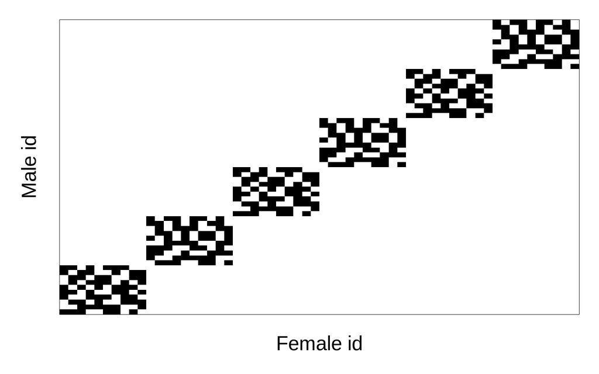

$n = 60$ and $K = 20$ in each cluster.

There is a square if a male and female mates.

## MCMC Estimate

```
## Inference for Stan model: salamander.
## 6 chains, each with iter=100000; warmup=20000; thin=1;
## post-warmup draws per chain=80000, total post-warmup draws=480000.
##
##          mean se_mean   sd  2.5%   25%   50%   75% 97.5%  n_eff Rhat
## beta[1]  0.63       0 0.26  0.13  0.45  0.62  0.80  1.16 176522    1
## beta[2] -0.43       0 0.29 -1.02 -0.63 -0.43 -0.23  0.14 225548    1
## beta[3] -1.81       0 0.35 -2.54 -2.04 -1.80 -1.57 -1.16 130912    1
## beta[4]  2.23       0 0.38  1.52  1.97  2.22  2.48  2.99 138428    1
## sigma_f  0.77       0 0.17  0.46  0.65  0.76  0.87  1.12  66649    1
## sigma_m  0.72       0 0.16  0.42  0.61  0.71  0.82  1.06  61948    1
##
## Samples were drawn using NUTS(diag_e) at Thu Feb 20 10:48:52 2020.
## For each parameter, n_eff is a crude measure of effective sample size,
## and Rhat is the potential scale reduction factor on split chains (at
## convergence, Rhat=1).
```

## Laplace Approximation

Requires estimation of $K$-dimensional mode and inversion of a $K\times K$ matrix.

Very fast and scale well but heavily biased in some cases.

## Laplace Approximation Cont.

```
## Generalized linear mixed model fit by maximum likelihood (Laplace
##   Approximation) [glmerMod]
##  Family: binomial  ( probit )
## Formula: y ~ wsm * wsf + (1 | female) + (1 | male)
##    Data: sala
##      AIC      BIC   logLik deviance df.resid
##    432.2    455.5   -210.1    420.2      354
## Random effects:
##  Groups Name        Std.Dev.
##  female (Intercept) 0.626
##  male   (Intercept) 0.576
## Number of obs: 360, groups:  female, 60; male, 60
## Fixed Effects:
## (Intercept)          wsm          wsf      wsm:wsf
##       0.601       -0.419       -1.731        2.140
```

## CDF Approximation

C++ implementation which supports computation in parallel.

Run on an Intel® Core™ i7-8750H CPU compiled with gcc 8.3.0.

Uses the `mvkbrv` Fortran subroutine from the `mvtnorm` package to approximate the gradient.

Uses BFGS implementation in R’s (R Core Team 2019) `optim` function.

## CDF Approximation Result (Large Relative Error)

```
##
## fit_CDF_cpp_fast
## ----------------
##
## Fixed effects
## (Intercept)         wsm         wsf     wsm:wsf
##      0.6208     -0.4290     -1.7242      2.1243
##
## Random effect standard deviations
## 0.7073 0.6835
##
## Log-likelihood estimate -206.82
## Computation time 23.77/0.48/0.53 (seconds total/per func./per grad.)
```

## CDF Approximation Result (Small Relative Error)

[output not shown]

# Next Steps

## Hybrid Method

Lai and Shih (2003) suggest a hybrid Laplace and Monte Carlo method.

May be very fast when combined with methods from Genz (1992) and Genz and Monahan (1999).

## Variational Approximation (VA)

Girolami and Rogers (2006) and Consonni and Marin (2007) suggest a VA (Ormerod and Wand 2010).

Consonni and Marin (2007) shows that it works poorly in some cases.

## Conditional Density

$$\begin{align*}
p(\vec v_1\mid \vec V_2 \leq \vec v_2) &=
\phi^{(k_1)}(\vec v_1; \vec \xi_1, \mat\Xi_{11})
\frac
{\Prob(\vec V_2 \leq\vec v_2 \mid \vec V_1 = \vec v_1)}
{\Prob(\vec V_2 \leq\vec v_2)}\\
&\hspace{-60pt}= \phi^{(k_1)}(\vec v_1; \vec \xi_1, \mat\Xi_{11}) \\
&\hspace{-20pt}\cdot
\frac
{\Phi^{(k_2)}\left(
\vec v_2
- \mat\Xi_{21}\mat\Xi_{11}^{-1}(\vec v_1 - \vec\xi_1);
\vec \xi_2,
\mat\Xi_{22} - \mat\Xi_{21}\mat\Xi_{11}^{-1}\mat\Xi_{12}
\right)}
{\Phi^{(k_2)}\left(
\vec v_2; \vec \xi_2, \mat\Xi_{22}
\right)}
\end{align*}$$

Suggests that a skew-normal VA will work well.

Ormerod (2011).

Requires estimation of $\bigO{K^2}$ variational parameters.

# Conclusion

## Summary

Showed three classes of mixed models with very similar marginal log-likelihoods.

A variety of approximations are available.

Best choice depends on the setting.

Hybrid method may be useful.

One variational approximation seems unexplored.

# Thank You!

The presentation is at rpubs.com/boennecd/mix-probit-KTH.

The markdown is at github.com/boennecd/Talks.

Code and more examples at github.com/boennecd/mixprobit.

References are on the next slide.

# References

Barrett, Jessica, Peter Diggle, Robin Henderson, and David Taylor-Robinson. 2015. “Joint Modelling of Repeated Measurements and Time-to-Event Outcomes: Flexible Model Specification and Exact Likelihood Inference.” *Journal of the Royal Statistical Society: Series B (Statistical Methodology)* 77 (1): 131–48. doi:10.1111/rssb.12060.

Consonni, Guido, and Jean-Michel Marin. 2007. “Mean-Field Variational Approximate Bayesian Inference for Latent Variable Models.” *Computational Statistics & Data Analysis* 52 (2): 790–98. doi:https://doi.org/10.1016/j.csda.2006.10.028.

Cranley, R., and T. N. L. Patterson. 1976. “Randomization of Number Theoretic Methods for Multiple Integration.” *SIAM Journal on Numerical Analysis* 13 (6). Society for Industrial; Applied Mathematics: 904–14. http://www.jstor.org/stable/2156452.

Genz, Alan. 1992. “Numerical Computation of Multivariate Normal Probabilities.” *Journal of Computational and Graphical Statistics* 1 (2). Taylor & Francis: 141–49. doi:10.1080/10618600.1992.10477010.

Genz, Alan, and Frank Bretz. 2009. *Computation of Multivariate Normal and T Probabilities*. Lecture Notes in Statistics. Heidelberg: Springer-Verlag.

Genz, Alan, and John Monahan. 1999. “A Stochastic Algorithm for High-Dimensional Integrals over Unbounded Regions with Gaussian Weight.” *Journal of Computational and Applied Mathematics* 112 (1): 71–81. doi:https://doi.org/10.1016/S0377-0427(99)00214-9.

Genz, Alan, Frank Bretz, Tetsuhisa Miwa, Xuefei Mi, Friedrich Leisch, Fabian Scheipl, and Torsten Hothorn. 2020. *mvtnorm: Multivariate Normal and T Distributions*. https://CRAN.R-project.org/package=mvtnorm.

Girolami, M., and S. Rogers. 2006. “Variational Bayesian Multinomial Probit Regression with Gaussian Process Priors.” *Neural Computation* 18 (8): 1790–1817. doi:10.1162/neco.2006.18.8.1790.

Hajivassiliou, Vassilis, Daniel McFadden, and Paul Ruud. 1996. “Simulation of Multivariate Normal Rectangle Probabilities and Their Derivatives Theoretical and Computational Results.” *Journal of Econometrics* 72 (1): 85–134. doi:https://doi.org/10.1016/0304-4076(94)01716-6.

Hothorn, Torsten, Lisa Möst, and Peter Bühlmann. 2018. “Most Likely Transformations.” *Scandinavian Journal of Statistics* 45 (1): 110–34. doi:10.1111/sjos.12291.

Keast, P. 1973. “Optimal Parameters for Multidimensional Integration.” *SIAM Journal on Numerical Analysis* 10 (5): 831–38. doi:10.1137/0710068.

Lai, Tze Leung, and Mei-Chiung Shih. 2003. “A Hybrid Estimator in Nonlinear and Generalised Linear Mixed Effects Models.” *Biometrika* 90 (4). [Oxford University Press, Biometrika Trust]: 859–79. http://www.jstor.org/stable/30042093.

Liu, Qing, and Donald A. Pierce. 1994. “A Note on Gauss-Hermite Quadrature.” *Biometrika* 81 (3). [Oxford University Press, Biometrika Trust]: 624–29. http://www.jstor.org/stable/2337136.

Liu, Xing-Rong, Yudi Pawitan, and Mark Clements. 2016. “Parametric and Penalized Generalized Survival Models.” *Statistical Methods in Medical Research* 27 (5): 1531–46. doi:10.1177/0962280216664760.

Liu, Xing-Rong, Yudi Pawitan, and Mark S. Clements. 2017. “Generalized Survival Models for Correlated Time-to-Event Data.” *Statistics in Medicine* 36 (29): 4743–62. doi:10.1002/sim.7451.

McFadden, Daniel. 1984. “Chapter 24 Econometric Analysis of Qualitative Response Models.” In, 2:1395–1457. Handbook of Econometrics. Elsevier. doi:https://doi.org/10.1016/S1573-4412(84)02016-X.

Niederreiter, H. 1972. “On a Number-Theoretical Integration Method.” *Aequationes Mathematicae* 8 (3): 304–11. doi:10.1007/BF01844507.

Ochi, Y., and Ross L. Prentice. 1984. “Likelihood Inference in a Correlated Probit Regression Model.” *Biometrika* 71 (3). [Oxford University Press, Biometrika Trust]: 531–43. http://www.jstor.org/stable/2336562.

Ormerod, J. T. 2011. “Skew-Normal Variational Approximations for Bayesian Inference.” *Unpublished Article*.

Ormerod, J. T., and M. P. Wand. 2010. “Explaining Variational Approximations.” *The American Statistician* 64 (2). Taylor & Francis: 140–53. doi:10.1198/tast.2010.09058.

Pawitan, Y., M. Reilly, E. Nilsson, S. Cnattingius, and P. Lichtenstein. 2004. “Estimation of Genetic and Environmental Factors for Binary Traits Using Family Data.” *Statistics in Medicine* 23 (3): 449–65. doi:10.1002/sim.1603.

Pinheiro, José C., and Douglas M. Bates. 1995. “Approximations to the Log-Likelihood Function in the Nonlinear Mixed-Effects Model.” *Journal of Computational and Graphical Statistics* 4 (1). American Statistical Association, Taylor & Francis, Ltd., Institute of Mathematical Statistics, Interface Foundation of America: 12–35. http://www.jstor.org/stable/1390625.

R Core Team. 2019. *R: A Language and Environment for Statistical Computing*. Vienna, Austria: R Foundation for Statistical Computing. https://www.R-project.org/.

Royston, Patrick, and Mahesh K. B. Parmar. 2002. “Flexible Parametric Proportional-Hazards and Proportional-Odds Models for Censored Survival Data, with Application to Prognostic Modelling and Estimation of Treatment Effects.” *Statistics in Medicine* 21 (15): 2175–97. doi:10.1002/sim.1203.